# Bayesian posteriors for the Cabrera link categories

Overview, results and conclusions for discussion

Kesem Abramov

31 October 2026

> Every candidate link at Cabrera carries eight posterior probabilities, one per link category, instead of a single hard label. 4 of the eight categories behave the way they claim to when tested against camera records the posterior never saw. Replication saturates within the six-site design.

| Quantity | Value |
| --- | --- |
| Candidate links, six sites | 1,624 |
| In the predicted site’s camera grid | 951 (59%) |
| Camera records among them | 262 |
| Prior and model settings compared | 4 |
| Categories confirmed against cameras in all four settings | 4 of 8 |
| Ceiling on confidence for a link not seen locally | 0.533 |

# Overview

## Motivation

The framework sorts every candidate link into one of eight categories using three yes/no facts: does the model predict it, was it seen at this site, was it seen at another site in the same system. Three bits, eight boxes.

This answer is a **label**. A link that only just qualified looks identical to one that clearly belongs, and the label says nothing about which links to chase or what would settle the question.

The posterior replaces the label with a probability spread across all eight categories. It says how much of a link’s evidence really supports its assigned category, which alternative the doubt points toward, and what the cheapest way to raise confidence would be.

## What the pipeline does

1. **Estimates the error rates** from the data itself.
2. **Calibrates the raw model scores** so they read as probabilities, and checks that the hard categorisation is unchanged.
3. **Builds one posterior function** holding every ingredient from the SI.
4. **Checks that function against the SI’s published worked values.**
5. **Runs it under four settings** of prior and model handling.
6. **Produces** category maps, category distributions, a test against camera records, and an evidence-accumulation curve.

**Methodological decisions.** The posterior is one function, and each setting below is an argument to it rather than a separate implementation, so the equation in the manuscript and the code cannot drift apart. Calibration is Platt scaling fitted **site-blocked**, so no site calibrates itself. Platt is monotone and therefore cannot reorder links, which we verify rather than assert: the hard predictions survive intact and only the number on the threshold moves.

## The posterior

Each candidate link $i$ carries four pieces of evidence $E_i$:

- $\hat Y_i \in \{0,1\}$, whether the model predicts it
- $O_{l,i} \in \{0,1\}$, whether it was recorded at the focal site
- $R$, the number of replicates, which is every site except the focal one, the same for every link
- $n_i \le R$, how many of those replicates recorded the interaction

Each category is one combination of three **true** states, which the evidence reports with error: $z_Y$, an error-free model would predict it; $z_l$, it is realised at the focal site; $z_r$, it is realisable in the replicates.

| Category | $z_Y$ | $z_l$ | $z_r$ |
| --- | --- | --- | --- |
| recurrent | 1 | 1 | 1 |
| locally unique | 1 | 1 | 0 |
| possibly missing | 1 | 0 | 1 |
| phantom | 1 | 0 | 0 |
| model-elusive | 0 | 1 | 1 |
| weakly-supported | 0 | 1 | 0 |
| locally absent | 0 | 0 | 1 |
| possibly forbidden | 0 | 0 | 0 |

The probability that link $i$ belongs to category $k$ is the prior times three likelihood factors, rescaled so the eight probabilities sum to one:

$$P(k \mid E_i) \;=\; \frac{\pi(k)\; L_Y(k)^{\,s}\; L_l(k)\; L_r(k)}
{\sum_{k'} \pi(k')\; L_Y(k')^{\,s}\; L_l(k')\;
L_r(k')}$$

$s$ switches the model factor on ($s = 1$) or off ($s = 0$); the settings below say when.

**Model factor.** The model agrees with the true state at rate $1-\epsilon_Y$:

$$L_Y = \begin{cases} 1-\epsilon_Y & \text{if } \hat Y = z_Y \\
\epsilon_Y & \text{if } \hat Y \neq z_Y \end{cases}$$

**Local factor.** A realised link is missed at rate $\epsilon_l$; an unrealised one is recorded spuriously at rate $f$:

$$L_l = \begin{cases}
1-\epsilon_l \text{ if } O_l = 1, \quad \epsilon_l \text{ if } O_l = 0
& \text{when } z_l = 1 \\
f \text{ if } O_l = 1, \quad 1-f \text{ if } O_l = 0 & \text{when }
z_l = 0
\end{cases}$$

**Replicate factor.** The chance of $n$ detections in $R$ sites. A realisable link is detected at a rate that varies between links, with mean $p_1$ and concentration $\nu$ (a beta-binomial). A non-realisable link is detected only by mistake, at rate $f$ (a binomial):

$$L_r = \begin{cases}
\dfrac{B(n+a,\; R-n+b)}{B(a,\,b)}, \quad a = p_1\nu,\; b = (1-p_1)\nu
& \text{when } z_r = 1 \\[2ex]
f^{\,n}\,(1-f)^{R-n} & \text{when } z_r = 0
\end{cases}$$

$B$ is the beta function. The binomial coefficient is left out because it is the same for every category and cancels.

**Methodological decision: every other site is a replicate.** A link can go unrecorded at a replicate because the partners were not there, or because they were there and the interaction was not realised or not detected. The SI does not separate these: both sit inside the per-replicate rate $p_1 = \rho\,(1-\epsilon_l)$, where the realisation rate $\rho$ is the whole ecological step, co-occurrence included (SI Section S4, Table S7). So $R$ counts every other site for every link, including sites where the two partners were never recorded together.

There is also an ecological reason not to drop those sites. A species enters a site’s data only if it was recorded interacting there, and co-occurring species are not always detected. A site without both partners in its data may well have held both, so excluding it would treat an undetected species as an absent one.

**Prior.** One probability per true state, multiplied:

$$\pi(k) = \pi_Y^{\,z_Y}(1-\pi_Y)^{1-z_Y}\;\;
\pi_l^{\,z_l}(1-\pi_l)^{1-z_l}\;\; \pi_r^{\,z_r}(1-\pi_r)^{1-z_r}$$

Setting all three to $\tfrac12$ gives every category $\tfrac18$, the uniform prior.

## The rates

| Rate | Meaning | Value |
| --- | --- | --- |
| $\epsilon_Y$ | model error, 1 - balanced accuracy | 0.276 |
| $\epsilon_l$ | chance direct observation misses a link that is present | 0.340 |
| $f$ | chance a record is spurious | 0.05 |
| $p_1$ | chance a replicate site records a link that is present | 0.103 |
| $\nu$ | how variable that chance is between links | 53.01 |

**Methodological decisions.**

$\epsilon_Y$ is one minus the balanced accuracy of the leave-one-site-out predictions against direct observation, one rate for both directions of error:

$$\epsilon_Y = 1 - \frac{1}{2}\left(\frac{TP}{TP+FN} +
\frac{TN}{TN+FP}\right)$$

$\epsilon_l$ comes from the camera contrast: both methods watch the same site at the same time, so the difference between them is detection alone. Over the pairs both methods had in play, with $O$ the links recorded by direct observation and $C$ those recorded by camera:

$$\epsilon_l = 1 - \frac{|O \cap C|}{|C|}$$

Conditioning on the links the **cameras** recorded makes the estimate directional, as “chance of missing something present” requires.

This is the **Lincoln-Petersen two-sample estimator**, the classic capture-recapture method. Two independent surveys of the same population give an estimate of the population’s total size:

$$\hat N = \frac{|O| \; |C|}{|O \cap C|}$$

Here the population is the interactions present, the first survey is direct observation and the second is the cameras. The share of that population direct observation records is $|O| / \hat N$, and substituting $\hat N$ gives exactly the expression above:

$$\frac{|O|}{\hat N} = \frac{|O \cap C|}{|C|}
\qquad\Longrightarrow\qquad
\epsilon_l = 1 - \frac{|O|}{\hat N} = 1 - \frac{|O \cap C|}{|C|}$$

The estimate is unbiased when the two methods miss links independently. Where both tend to miss the same hard links, it understates $\epsilon_l$.

A symmetric alternative gives the wrong answer: $1 -$ Jaccard would be 0.55, because it also charges direct observation for links the *cameras* missed.

$f$ is the one rate nothing in the data identifies, because the usual negative control (pairs that never co-occur) is excluded from the candidate set by construction. It is fixed a priori.

$p_1$ and $\nu$ maximise a zero-truncated beta-binomial likelihood over the 294 species pairs recorded at one or more sites. Every site is a trial for every pair, so $R_j$ = 6 for all of them, and $n_j$ is the number of sites that recorded the interaction. This is the SI’s own estimate of $p_1$, the proportion of networks in which the interaction is recorded (SI Section S9), so $p_1$ covers the absent-partner step as well as realisation and detection:

$$\ell(p_1, \nu) = \sum_j \log \frac{BB(n_j \mid R_j)}{1 - BB(0 \mid
R_j)},
\qquad BB(n \mid R) = \frac{B(n+a,\; R-n+b)}{B(a,\,b)}$$

with $a$ and $b$ as in the replicate factor. Dividing by $1 - BB(0 \mid R_j)$ corrects for having kept only pairs recorded at least once, which would otherwise bias $p_1$ upward. The binomial coefficient is again left out: it does not depend on $p_1$ or $\nu$, so it moves neither the fit nor the comparison below.

**Open question.** 342 links (21%) sit at the floor of the prediction pipeline’s sigmoid and carry no model information to calibrate. **Closed: we converted the sigmoid use in the Bayesian example to Platt scaling with no conversion of negative predictions.**

## The four settings

|  | uniform prior | degree-based prior |
| --- | --- | --- |
| **A** model enters through the posterior as $\delta$ | A-uniform | A-degree |
| **B** calibrated model score enters as the prior | B-uniform | B-degree |

Degree priors are global and replicate-based, so a link between two well-connected species starts with more prior weight on the present-side categories.

**Methodological decisions.** Four settings rather than one, because the prior is the most arguable choice in the whole construction. Showing that a conclusion holds in all four is stronger than defending any single prior.

Each setting fixes two things in the posterior equation: the model switch $s$ and the three prior probabilities.

$s$ is the exponent on the model factor, $L_Y^{\,s}$. With $s = 1$ the factor counts as usual, so the model enters as **evidence**. With $s = 0$ it becomes $L_Y^{\,0} = 1$ for every category and drops out, so the model can enter through the **prior** instead. Using both would count the model twice.

| Setting | $s$ | $\pi_Y$ | $\pi_l$ | $\pi_r$ |
| --- | --- | --- | --- | --- |
| A-uniform | 1 | $\tfrac12$ | $\tfrac12$ | $\tfrac12$ |
| A-degree | 1 | $\tfrac12$ | $\pi_l^{\deg}$ | $\pi_r^{\deg}$ |
| B-uniform | 0 | $q_i$ | $\tfrac12$ | $\tfrac12$ |
| B-degree | 0 | $q_i$ | $\pi_l^{\deg}$ | $\pi_r^{\deg}$ |

$q_i$ is the Platt-calibrated score. The pipeline’s `probability` column $p_i$ is inverted back to the raw score $x_i$, and a logistic regression of the local record on that score, fitted on the other five sites, turns it into a probability:

$$x_i = \log\frac{p_i}{1-p_i}, \qquad q_i = \frac{1}{1 + e^{-(\alpha +
\beta x_i)}}$$

The degree prior is the configuration-model chance that two species connect, given their degrees, then given five tries for the replicates:

$$\pi_l^{\deg} = \min\!\left(\frac{d_{\text{pol}}\; d_{\text{pla}}}{L},\;
0.99\right),
\qquad \pi_r^{\deg} = 1 - \left(1 - \pi_l^{\deg}\right)^{5}$$

$d_{\text{pol}}$ and $d_{\text{pla}}$ count the observed links of the pollinator and the plant, and $L$ all observed links, each taken from the five non-focal sites only, so the prior never sees the evidence it is combined with.

**Open question.** A and B may be redundant for the camera test. Under a product prior the posterior factorises into three independent parts, and the local part does not depend on the model bit, so any test keyed to the local axis cannot separate A from B. The camera results below bear this out exactly. Worth deciding whether the manuscript presents four settings or two.

## A second axis: the likelihood

The four settings above vary the **prior**, and all of them assume links differ in how readily a replicate site records them, governed by $\nu$. Each one therefore gets a **twin** with that heterogeneity removed: A-uniform (no nu), A-degree (no nu), and so on. Eight runs, four pairs.

Every prior needs its own twin rather than testing $\nu$ once. $\nu$ enters the replicate factor for the four categories that claim the link is realisable elsewhere, and the posterior is normalised, so how far a change there moves the final probabilities depends on how much prior weight sat on those categories to begin with. A uniform prior spreads that weight evenly; a degree prior concentrates it on well-connected pairs. Testing $\nu$ under the uniform prior alone would test it where it has the least room to matter, and the degree runs are the ones carrying the within-category ranking.

**Methodological decisions.** Removing heterogeneity means **removing** $\nu$, not estimating it as infinite: the binomial is the beta-binomial at $\nu \to \infty$. Under that constraint $p_1$ is the only free parameter left and has to be **refitted**, because the mean of a beta-binomial is not the binomial MLE. Here that matters: 0.103 against 0.117 on the same 294 species pairs.

The twins are derived from the same list of priors in code rather than written out again, so a change to a prior cannot reach one twin and miss the other.

In a twin, the replicate factor for $z_r = 1$ becomes a plain binomial, $L_r = p_1^{\,n}(1-p_1)^{R-n}$, and $p_1$ is refitted with the same zero truncation:

$$\ell(p_1) = \sum_j \log
\frac{p_1^{\,n_j}(1-p_1)^{R_j-n_j}}{1-(1-p_1)^{R_j}}$$

The two models are nested, so which one the data prefer is a test rather than a preference:

$$LR = 2\,\bigl(\hat\ell_{\text{with }\nu} - \hat\ell_{\text{without
}\nu}\bigr),
\qquad p = \tfrac12\, P\!\left(\chi^2_1 > LR\right),
\qquad \Delta AIC = 2 - LR$$

$LR$ is twice the gain in fit from adding $\nu$. $p$ is the chance of a gain that large if all links truly shared one rate; it is halved because “no heterogeneity” is $\nu \to \infty$, the edge of its possible range. $\Delta AIC$ is AIC with $\nu$ minus AIC without, where AIC $= 2 \times$ (parameters) $- \, 2\hat\ell$; negative means $\nu$ is worth its extra parameter.

| Model | log-likelihood | $p_1$ | $\nu$ | AIC |
| --- | --- | --- | --- | --- |
| beta-binomial (heterogeneous) | -822.69 | 0.103 | 53.01 | 1649.4 |
| binomial (no $\nu$) | -822.91 | 0.117 | removed | 1647.8 |

The likelihood ratio is 0.44 on 1 df, boundary-corrected $p$ = 0.253, so **the data give no support for keeping $\nu$ (or no reason to drop it?)**. The twins show what that choice does to the results.

# The starting point

The deterministic assignment at the richest site. Each cell is one candidate link, coloured by its single assigned category.

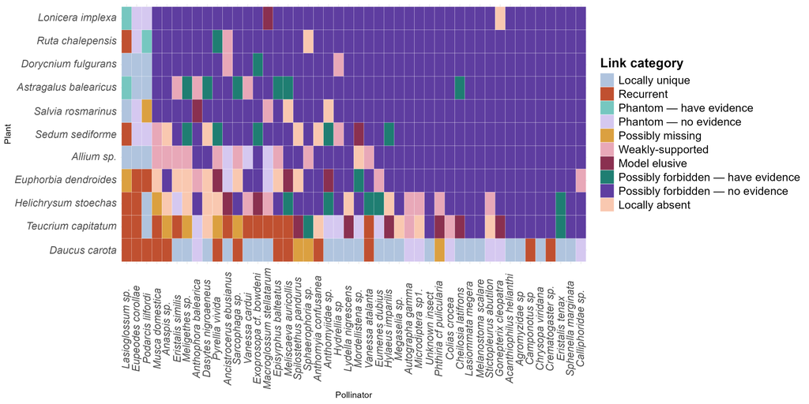

This is the reference the posterior is compared against. It is complete and unambiguous, and that is the problem: nothing in it separates a link the evidence strongly supports from one that only just fell on that side of a boundary.

**Takeaway.** The deterministic map is a reference, not a truth. Anything the posterior does differently has to be judged against independent evidence, not against this figure.

# Results

Categories appear in taxonomy order: the predicted classes first, then the unpredicted class that dominates the candidate set.

In every map below, each cell is one link $i$ and **colour intensity is $P(k \mid E_i)$** for the category $k$ the figure is about. A **black frame** marks cells the deterministic rule assigned to $k$, and an **asterisk** marks a link the cameras recorded. All four panels of a figure share one colour scale, so shades are comparable between settings. All heatmaps are of the most species-rich site.

## Possibly missing

Predicted, recorded at other sites, not recorded here. The framework’s highest-priority category, and the one where the prescribed action is simply more effort with the same method.

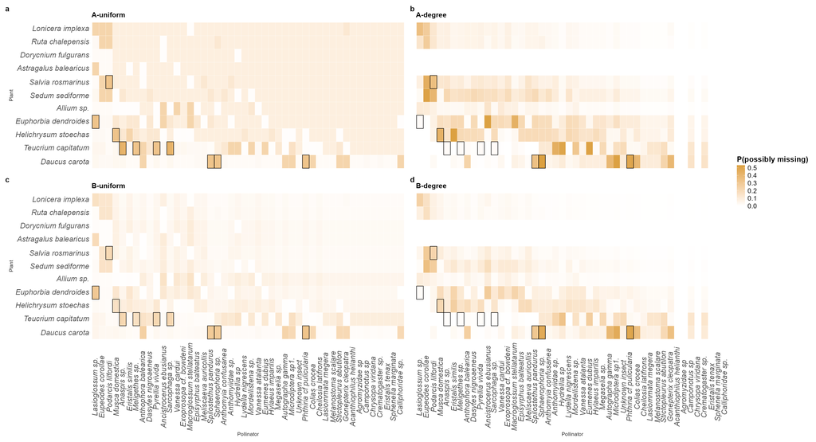

A-uniform is the counterpart of the deterministic assignment and B-uniform looks much like it. The degree-based priors visibly change the picture.

| Setting | Links | Mean posterior on the assigned category | Most likely category is the assigned one |
| --- | --- | --- | --- |
| A-uniform | 51 | 0.338 | 100% |
| A-degree | 51 | 0.273 | 47% |
| B-uniform | 51 | 0.246 | 49% |
| B-degree | 51 | 0.207 | 20% |

**Methodological decisions.** Frames come from the deterministic rule and are identical in all four panels, so any difference between panels is the prior talking and nothing else.

The table’s two columns, over the $N$ links the hard rule assigned, with $k^{\det}_i$ the category it gave link $i$:

$$\text{mean posterior} = \frac{1}{N}\sum_i P\!\left(k^{\det}_i \mid
E_i\right),
\qquad
\text{agreement} = \frac{1}{N}\sum_i \mathbb{1}\!\left[\,\arg\max_k P(k
\mid E_i) = k^{\det}_i\right]$$

The first is how much probability each link puts on its assigned category; the second is how often that category is also its most probable one.

**Takeaway.** The label and the confidence are different quantities. A link can sit in possibly missing under the hard rule while the posterior puts most of its weight elsewhere. That is not a bug: the hard rule reads three bits as if they were certain, and the posterior does not.

## Possibly forbidden

Neither predicted nor recorded anywhere: 941 of 1,624 links, by far the largest category.

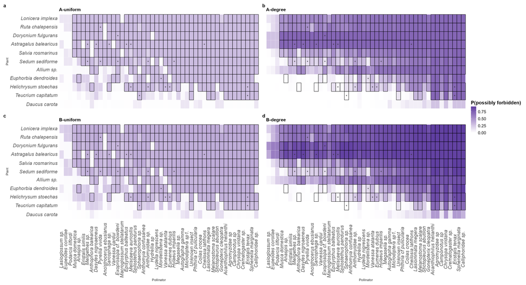

**Takeaway.** Triage matters most here. A category holding well over half the grid is unusable as a to-do list. The posterior orders it, and the cameras corroborate that ordering, as shown two sections below.

**Discuss** Which model to use?

## Phantom

Predicted, but recorded nowhere. Genuinely ambiguous: either the model is wrong, and an independent method finds nothing, or the interaction is invisible to the method in use, and it does. The two readings predict opposite outcomes, which is why the prescribed action is a different method rather than more effort.

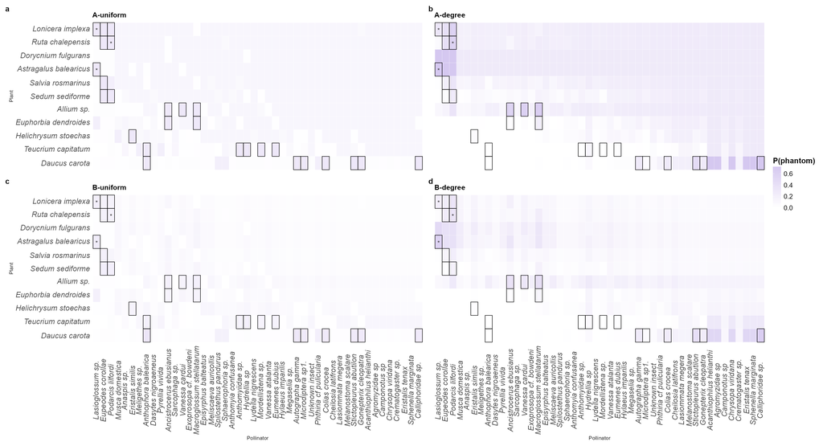

**Takeaway.** Phantom is the one category with no predicted direction, so the camera test below cannot confirm or refute it. The framework says as much already, and the data does not contradict it.

## Where the posterior weight goes

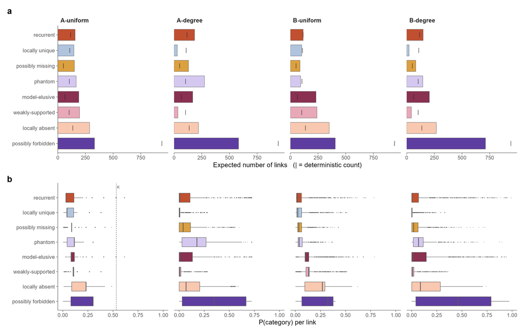

Panel **a** is the expected number of links per category, panel **b** the spread of per-link posteriors. The tick in panel a is the deterministic count, the same in all four panels, so the gap between tick and bar is exactly what each prior moves. Results are across all sites.

| Setting | Mean posterior on the assigned label | Most likely category is the assigned one | Total gap from the deterministic counts |
| --- | --- | --- | --- |
| A-uniform | 0.332 | 100% | 1218 |
| A-degree | 0.458 | 69% | 1014 |
| B-uniform | 0.359 | 91% | 1109 |
| B-degree | 0.513 | 64% | 755 |

**Methodological decisions.** Once a label becomes a distribution, the honest headline number for a category is the **sum of its posterior column**, not a count of links. Panel a plots the expected count, and the table’s last column compares it with the deterministic count $N_k^{\det}$:

$$E[N_k] = \sum_i P(k \mid E_i),
\qquad
\text{total gap} = \sum_k \left|\, E[N_k] - N_k^{\det} \right|$$

The dashed line in panel b is the ceiling on confidence for a link not recorded locally, however many replicates record it:

$$\kappa = \frac{(1-\epsilon_Y)(1-f)}{(1-f)+\epsilon_l} = 0.533$$

It holds only when every prior probability is $\tfrac12$, so it is drawn only in the A-uniform panel; the other settings relax that condition and can exceed it.

Two things are worth pausing on. A-uniform reproduces the deterministic label most faithfully yet sits **farthest** from the deterministic counts, because it holds the least weight on that label and so spreads the most. And the degree settings are the **sharpest**, which is not the same as the most accurate.

**Takeaway.** Resembling the deterministic counts is not evidence of being right, because those counts are not truth. The next section supplies a criterion external to both.

Which of the two choices moves the posterior more, where the model enters or the prior? Each row compares two settings that differ in one choice only.

| Changed | Comparison | Total gap in expected counts | Mean change per link | Same most likely category |
| --- | --- | --- | --- | --- |
| where the model enters | A-uniform vs B-uniform | 443 | 0.069 | 90.9% |
| where the model enters | A-degree vs B-degree | 443 | 0.121 | 90.9% |
| prior | A-uniform vs A-degree | 775 | 0.305 | 69.0% |
| prior | B-uniform vs B-degree | 785 | 0.340 | 69.0% |

The total gap is $\sum_k |E[N_k]_a - E[N_k]_b|$ between the two settings, and the change per link is the largest shift in any one category, $\max_k |P(k \mid E_i)_a - P(k \mid E_i)_b|$.

**Takeaway.** The settings differ mostly through the prior, not through where the model enters. Moving the model from evidence to prior shifts at most 443 expected links and changes the most likely category of at most 9.1% of links. Adding the degree prior shifts at least 775 and changes at least 31.0%.

**B-degree is the only run in which the mean confidence in assignment is higher than 0.5 (might be an artifact how the model works).**

## Where does each category’s posterior go?

The distribution figure shows how many links each category ends up with. It does not show where they came from. Here every arrow follows the posterior from a deterministic category to another one, for all sites.

**Absolute weights.** Arrow width is the expected number of links moving.

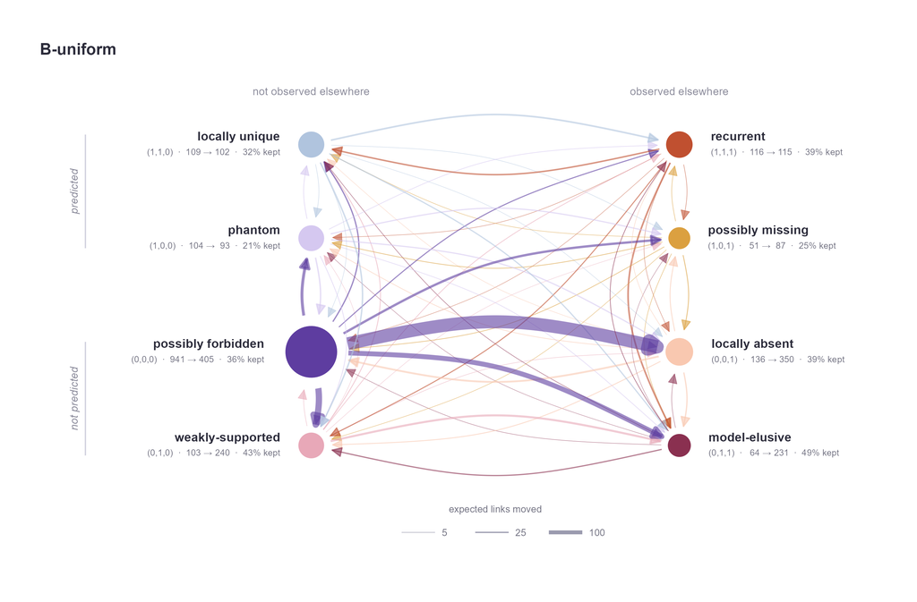

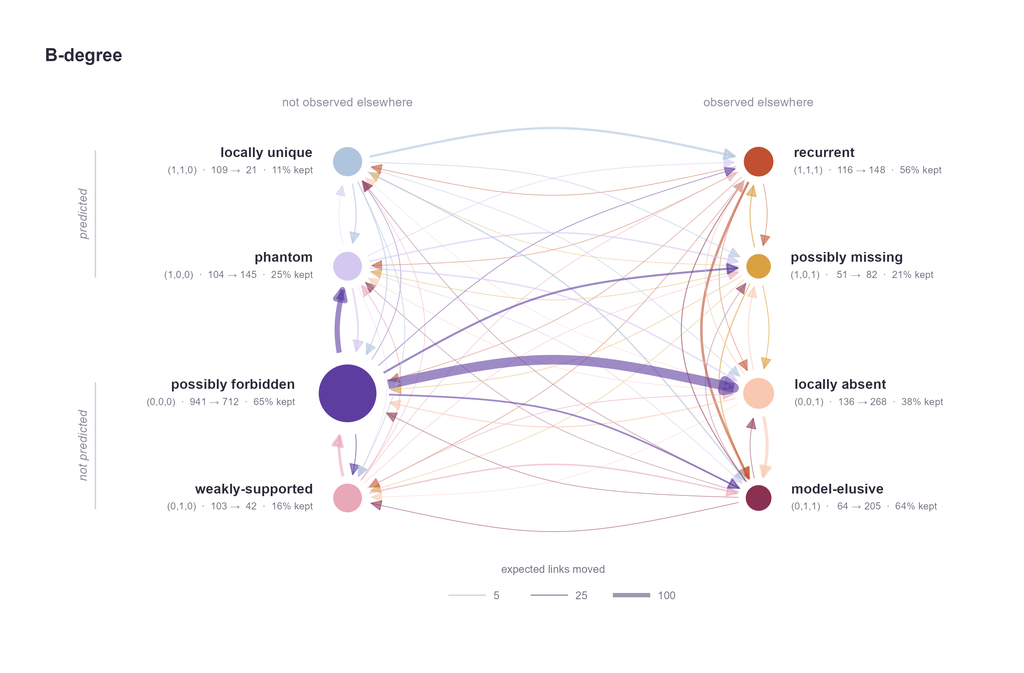

**Relative weights.** Arrow width is the share of the source category’s links moving.

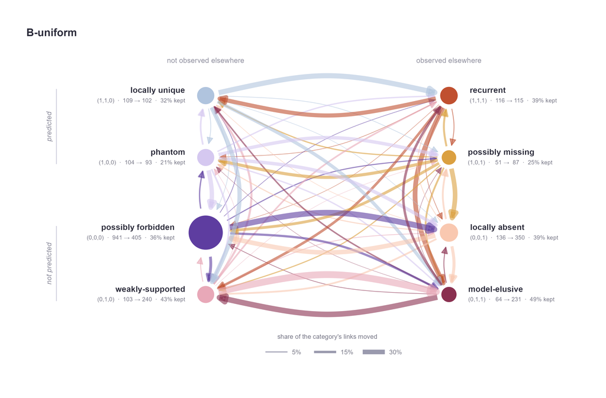

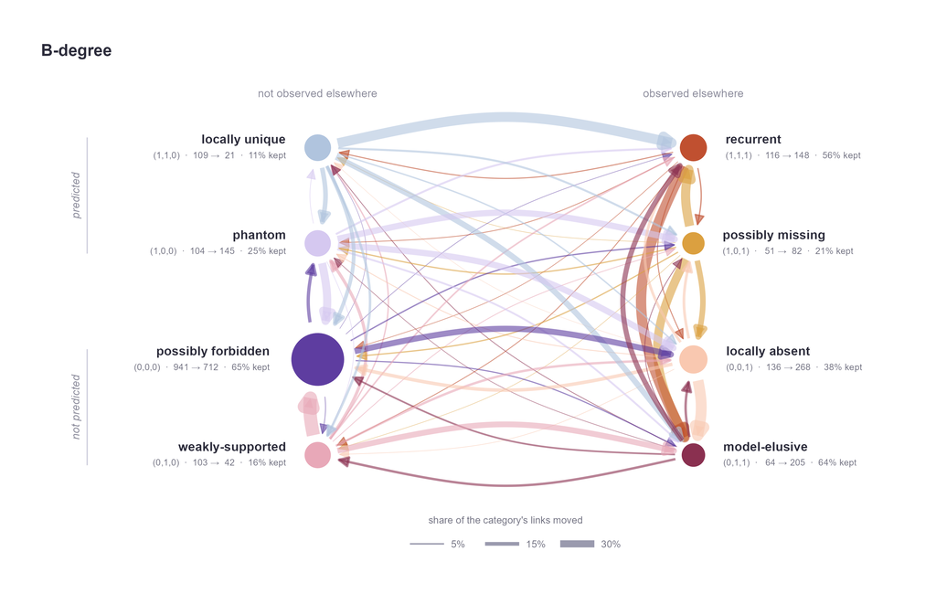

**Methodological decisions.** For a deterministic category $k$ with $N_k^{\det}$ links, the arrow to category $m$ carries

$$F_{k \to m} = \sum_{i:\,k^{\det}_i = k} P(m \mid E_i),
\qquad
\text{share}_{k \to m} = \frac{F_{k \to m}}{N_k^{\det}}$$

$F_{k \to k}$ is what the category keeps. A category’s outgoing arrows plus what it keeps add up to $N_k^{\det}$; its incoming arrows plus what it keeps add up to $E[N_k]$. Both numbers are on each node’s label, with the share kept.

*The two versions answer different questions.* The **absolute** version shows where most of the expected links go. Large categories dominate it by size alone. The **relative** version shows how stable each category is, whatever its size: a category that keeps little of its mass has a hard label we should trust less.

*Layout.* The taxonomy figure of the manuscript: columns are observed elsewhere or not, rows are predicted then not predicted. A move to a neighbouring node doubts one of the three bits; a diagonal move doubts two. Arrows take the colour of the category they leave, node area is the deterministic count, and each version uses one width scale for both runs.

*What moves is probability, not links.* No link switches category as a whole. Each keeps part of its posterior and spreads the rest.

**Takeaway.**

- In absolute numbers, the largest flow is possibly forbidden → locally absent under B-uniform (261 links) and possibly forbidden → locally absent under B-degree (171). Possibly forbidden is the largest category, so it dominates this view.
- Relative to size, possibly forbidden keeps 36% of its mass under B-uniform and 65% under B-degree, where it ranks first in stability. The least stable category is phantom under B-uniform (21% kept) and locally unique under B-degree (11% kept).
- Most moving mass goes to a neighbouring category, doubting one bit: 71% under B-uniform and 76% under B-degree. The biggest arrow in both runs, possibly forbidden → locally absent, crosses the replicate bit: with $p_1$ = 0.10, a link that can occur in the replicates still goes unrecorded at all 5 of them more often than not (probability 0.58 at the mean rate), so absence there is weak evidence.

## Does heterogeneity matter?

The same distribution figure for the four twins, in the same panel order, so it reads directly against the one above. Each panel differs from its counterpart by the **likelihood alone**: same prior, same model role, same rates, one carrying heterogeneous $p_1$ and the other the single $p_1$ refitted without it. Anything that moves between a panel and its counterpart is $\nu$, and nothing else.

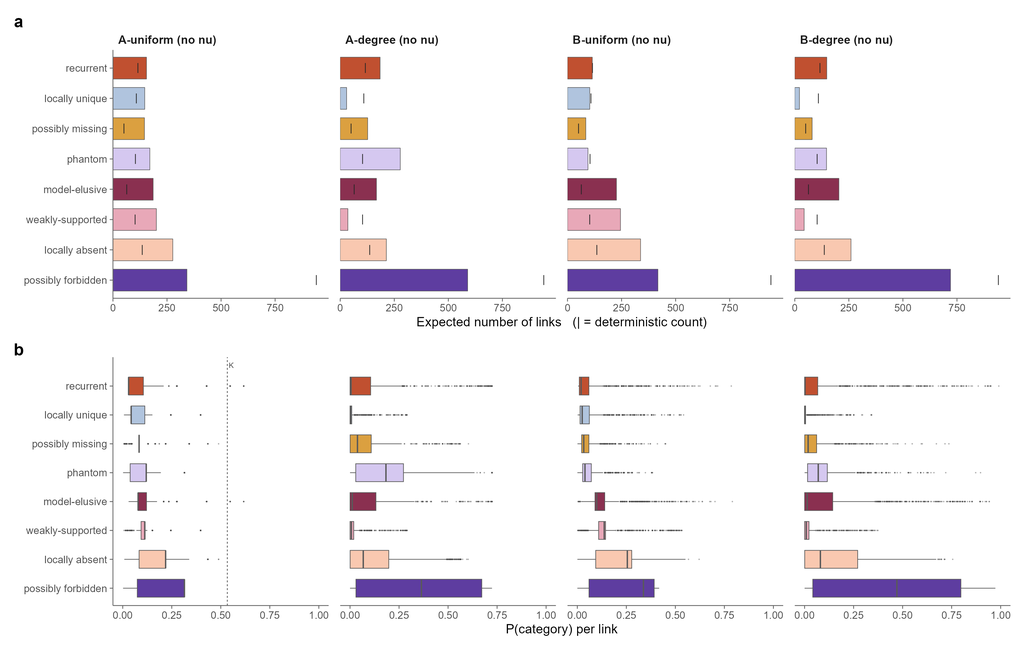

Expected links gained or lost per category when $\nu$ is removed, within each prior:

$$\Delta E[N_k] = E[N_k]_{\text{without }\nu} - E[N_k]_{\text{with }\nu}$$

Paired by prior, because the question is what $\nu$ does inside a prior, not which prior sits closest to the deterministic counts.

| Category | Deterministic | A-uniform | A-degree | B-uniform | B-degree |
| --- | --- | --- | --- | --- | --- |
| possibly forbidden | 941 | 10.3 | 6.6 | 12.6 | 8.0 |
| locally absent | 136 | -10.3 | -6.6 | -12.6 | -8.0 |
| recurrent | 116 | -1.4 | -0.7 | -0.5 | -0.6 |
| locally unique | 109 | 1.4 | 0.7 | 0.5 | 0.6 |
| phantom | 104 | 4.4 | 3.2 | 2.1 | 1.8 |
| weakly-supported | 103 | 4.0 | 0.8 | 4.9 | 0.9 |
| model-elusive | 64 | -4.0 | -0.8 | -4.9 | -0.9 |
| possibly missing | 51 | -4.4 | -3.2 | -2.1 | -1.8 |

The largest single shift is 12.6 links out of 1,624. $\kappa$ does not change at all, because $\nu$ does not appear in it.

The shifts come in equal and opposite pairs. Each category that says “realisable in the replicates” ($z_r = 1$) loses exactly what its partner saying “not realisable” ($z_r = 0$) gains: recurrent and locally unique, possibly missing and phantom, model-elusive and weakly-supported, locally absent and possibly forbidden. $\nu$ acts only through the replicate factor, so it can move probability only across $z_r$. Here the movement runs from “realisable in the replicates” toward “not realisable”.

Totals can hide movement at the level of single links, so the same comparison link by link, with $\Delta_i = \max_k \left| P(k \mid E_i)_{\text{without }\nu} - P(k \mid E_i)_{\text{with }\nu} \right|$:

| Setting | Mean change per link | Largest change | Links moving more than 0.05 | Same most likely category | Within-category rank correlation, lowest |
| --- | --- | --- | --- | --- | --- |
| A-uniform | 0.014 | 0.02 | 0 | 100.0% | NA |
| A-degree | 0.006 | 0.02 | 0 | 98.5% | 0.998 |
| B-uniform | 0.016 | 0.03 | 0 | 100.0% | 1.000 |
| B-degree | 0.007 | 0.03 | 0 | 98.5% | 1.000 |

The last column is the Spearman correlation between the two posteriors across each category’s own links, taken for possibly missing, phantom and possibly forbidden, and reporting the lowest of the three. 1 means removing $\nu$ leaves the ranking untouched.

The three category maps for the twins are below, one per corroboration action, each mirroring the four-run figure of the same category above.

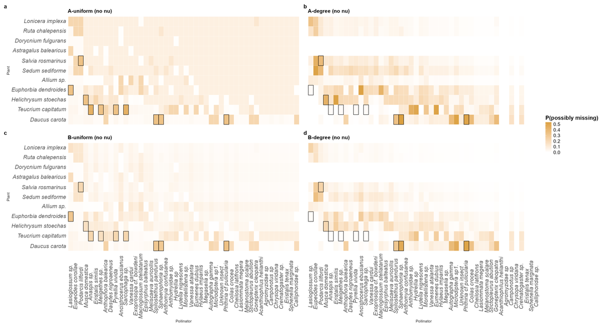

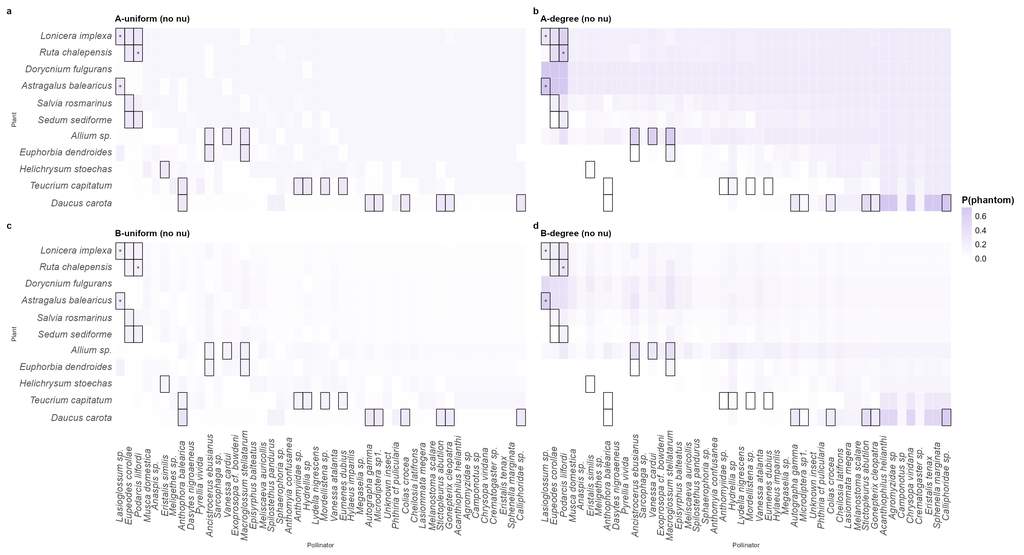

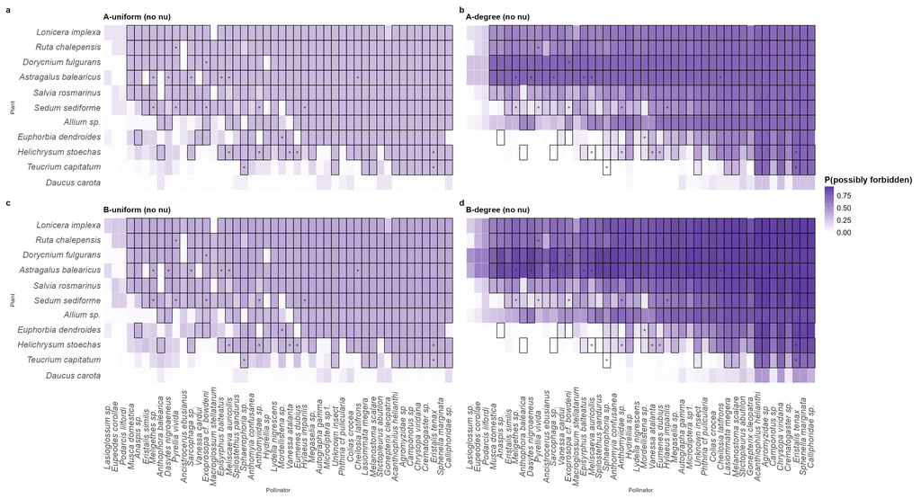

Each figure carries its own shared colour scale, so compare **shapes** between a figure and its counterpart above, and shades only within one figure.

**Takeaway.** Removing $\nu$ moves at most 13 expected links, from “realisable in the replicates” toward “not realisable”. The share of links whose most likely category changes is 0.0% at most under the uniform priors and 1.5% at most under the degree priors, so the priors do respond differently. Within-category rankings stay nearly identical (lowest Spearman NA), and 8 of the 8 camera calls are unchanged under every prior. The data give no support for keeping $\nu$ (boundary $p$ = 0.253).

## Does confidence buy anything?

The question the whole exercise turns on: if we chase the links the posterior is confident about, do we find more? For possibly forbidden the prediction runs the other way, so the test is whether cameras find **fewer** records among links with a high forbidden posterior.

**Methodological decisions.** This is the measurement to scrutinise, so it is worth being explicit about each choice.

*Independent evidence.* Cameras ran in parallel with direct observation and the posterior never saw them, so they are a fourth source of evidence rather than a restatement of the three the posterior uses.

*Where the evidence is sought.* A camera record is evidence about the **link**, not the category, so it is sought where the label leaves the link’s status open. What the label settles differs by category, because the model’s call is made at the predicted site only. The scope names below are the ones in the `Scope` column of the table.

- **all 6 sites** — *possibly forbidden.* Recorded nowhere and the model agrees, so feasibility is open everywhere and a record at any site bears on it.
- **other 5 sites** — *locally unique.* Presence at the predicted site is already established, so what is open is realisation elsewhere. A record there means the label was wrong.
- **here and elsewhere** — *recurrent.* The claim has two halves, presence at the predicted site and in the replicates, so both must be corroborated: a record at the predicted site *and* at one other.
- **predicted site** — *possibly missing, phantom, model-elusive, weakly-supported, locally absent.* Each makes a claim about the predicted site alone, so only that site’s records bear on it.

*Who is in the test.* Each scope also fixes who can answer it. A link is inside a site’s **camera grid** when both partners appear in that site’s camera data; a zero then means the cameras saw both species there but never together, which is a real negative. Links the scope never watched are dropped, since they can neither confirm nor refute. The four scopes therefore admit different samples, and *recurrent* has the smallest, because it needs a link watched at the predicted site and at one other. Counts are in the `n in test` column, and rows with different scopes are not comparable with one another.

*How agreement is measured.* One logistic regression per category per setting, predicting whether the cameras recorded a link from that category’s posterior. The effect is reported as an odds ratio per one standard deviation of the posterior, so categories with different spreads stay comparable.

*The adjustment that makes it a real test.* The direct observation is held fixed. Categories are defined partly by that observation, so without this the posterior would largely be re-describing it. Holding it fixed asks: among links whose direct observation was the same, does the posterior still say which ones the cameras find? A second model also adjusts for site, since camera coverage differs between sites.

*The model.* For category $k$, over the links its scope admits, with $c_i = 1$ when the cameras recorded link $i$ within that scope:

$$\log\frac{P(c_i = 1)}{1 - P(c_i = 1)} = \beta_0 + \beta_1 z_i + \beta_2
O_{l,i},
\qquad
z_i = \frac{P(k \mid E_i) - \overline{P}}{\operatorname{sd}(P)}$$

$z_i$ is the posterior standardised to mean 0 and standard deviation 1, and the site-adjusted version adds one term per site. The table reports

$$OR = e^{\beta_1}$$

the factor by which the **odds** of a camera record change for one standard deviation more posterior. Above 1, higher posterior goes with more records.

*The probability column.* An odds ratio is not a change in probability, so the same fit is translated back. Every link is predicted twice, at the average posterior ($z = 0$) and one standard deviation above it ($z = 1$), keeping its own $O_l$, and the predictions are averaged:

$$\bar p_0 = \frac{1}{N}\sum_i \sigma\!\left(\hat\beta_0 + \hat\beta_2
O_{l,i}\right),
\qquad
\bar p_1 = \frac{1}{N}\sum_i \sigma\!\left(\hat\beta_0 + \hat\beta_1 +
\hat\beta_2 O_{l,i}\right),
\qquad
\sigma(x) = \frac{1}{1+e^{-x}}$$

The table shows $\bar p_0 \to \bar p_1$ in percent, ranged over the settings where the effect is significant.

*The verdict.* A setting supports a category when $p < 0.05$ for $\beta_1$ and $OR$ falls on the side the category claims: above 1 for “higher”, below 1 for “lower”.

*The expected direction* is set from what each category **claims ecologically**, not from its observation bit. These differ. Possibly missing carries “not seen here”, yet its whole claim is that the interaction is present and was missed, so cameras should find it *more* often. The direction is read against the scope, not against camera records in general: locally unique expects *fewer* records, because at the other five sites a genuinely unique link should not be found, and a record there means the label was wrong.

| Category | Expect | Scope | n | Camera-confirmed | % | n in test | A-uniform | A-degree | B-uniform | B-degree | Verdict | Site-adjusted | no_nu | Camera chance, mean -> +1 SD |
| --- | --- | --- | --- | --- | --- | --- | --- | --- | --- | --- | --- | --- | --- | --- |
| recurrent | higher | here and elsewhere | 94 | 55 | 59 | 585 | 2.14*** | 1.75*** | 2.25*** | 1.91*** | supported in 4/4 | holds | 4/4 same | 18 -> 28-32 |
| locally unique | lower | other 5 sites | 61 | 28 | 46 | 884 | 0.77* | 0.87 | 1.00 | 0.89 | supported in 1/4 | 0 of 1 | 4/4 same | 34 -> 30 |
| possibly missing | higher | predicted site | 34 | 13 | 38 | 951 | 1.55*** | 1.38*** | 1.54*** | 1.36*** | supported in 4/4 | holds | 4/4 same | 28-29 -> 32-35 |
| phantom | unclear | predicted site | 74 | 11 | 15 | 951 | 1.16 | 0.85 | 1.31** | 0.96 | no direction predicted (1/4 signal) | NA | 4/4 same | 28 -> 32 |
| model-elusive | higher | predicted site | 54 | 28 | 52 | 951 | 0.79* | 1.03 | 0.78* | 1.03 | CONTRADICTED in 2/4 | holds | 4/4 same | 29 -> 25 |
| weakly-supported | lower | predicted site | 66 | 27 | 41 | 951 | 0.68*** | 0.80** | 0.68*** | 0.81** | supported in 4/4 | holds | 4/4 same | 28-29 -> 24-25 |
| locally absent | lower | predicted site | 94 | 20 | 21 | 951 | 0.84 | 1.30** | 0.78 | 1.32** | CONTRADICTED in 2/4 | holds | 4/4 same | 28 -> 32 |
| possibly forbidden | lower | all 6 sites | 638 | 80 | 13 | 1250 | 0.35*** | 0.42*** | 0.24*** | 0.41*** | supported in 4/4 | holds | 4/4 same | 30-31 -> 9-18 |

Reading the table: the setting columns are odds ratios per one standard deviation of that category’s posterior, with the direct observation held fixed. Above 1, a higher posterior goes with more camera records. Stars are `***` $p<0.001$, `**` $p<0.01$, `*` $p<0.05$. The last column translates the same effect onto the probability scale, which is the figure to quote in prose.

The `no_nu` column is the heterogeneity check. Eight odds-ratio columns would be unreadable, and the question the twins answer is narrow: does removing $\nu$ change the **call**? A call is “significant and upward”, “significant and downward”, or “no signal”, which is what the verdict is built from. Each twin is compared with its own prior, so `4/4 same` means $\nu$ changes nothing for that category under any of the four priors.

`n` counts links of that category **within its scope sample**, not the whole category: possibly forbidden has 941 links in total and 638 here. `n in test` is that sample in full, which is what the regression uses.

4 categories are supported in all 4 settings, and 4 of those 4 still hold after the site adjustment:

- **recurrent** and **possibly missing** go the right way upward. Possibly missing is the one that matters, because its claim is that the interaction is present and direct observation missed it.
- **weakly-supported** and **possibly forbidden** go the right way downward. For possibly forbidden, one standard deviation up the posterior takes the chance of a camera record from 30-31% to 9-18%, ranged over the settings.

Two of the four draw on evidence from beyond the predicted site, and in each case the scope is the one the claim implies: possibly forbidden against records at all six sites, since it asserts the interaction is infeasible anywhere, and recurrent against a record at the predicted site *and* at one other, since its claim has both halves. Restricting either to the predicted site would count a record the cameras made elsewhere as a non-detection of a claim that was never about one site, which weakens the test rather than tightening it.

**Takeaway.** The posterior is not merely re-describing the observations. Holding the direct observation fixed, it still orders links by how likely an independent method is to find them, in the direction each category claims. That is the operational value of the confidence layer: it turns a category into a ranked list, which is what makes a category of 941 possibly-forbidden links actionable at all.

**Open questions.**

- **Locally absent contradicts its expected direction** in the two degree settings. Its claim is that the link is feasible in the system but not realised here, so cameras should find it less often, and under degree priors they find it more. This needs an explanation before it reaches the manuscript.
- **Locally unique is the weakest directional test.** Tested at the other five sites, where a genuinely unique link should not be found, it reaches significance under one prior of four (supported in 1/4). The evidence is thin by construction: a record at another site overturns the label rather than confirming it, so the category has no corroborating outcome of its own, only a refuting one. Whether that belongs in the same table as the categories a camera record can confirm is worth deciding before the manuscript.
- $\epsilon_l$ is fitted on the same camera records this test uses. Holding the direct observation fixed limits the exposure, since $\epsilon_l$ enters through the local axis, but a leave-one-site-out refit would remove what remains.

## Where to look, species by species

Field effort is often planned per species: a camera or an extra observation round goes to a plant. Two steps: first all plants at Rocky coastal 1 side by side, then one plant at a time.

### Step 1: all plants, category by category

For each of the 11 plants, how many of its 46 candidate links the posterior places in each category (most species rich site).

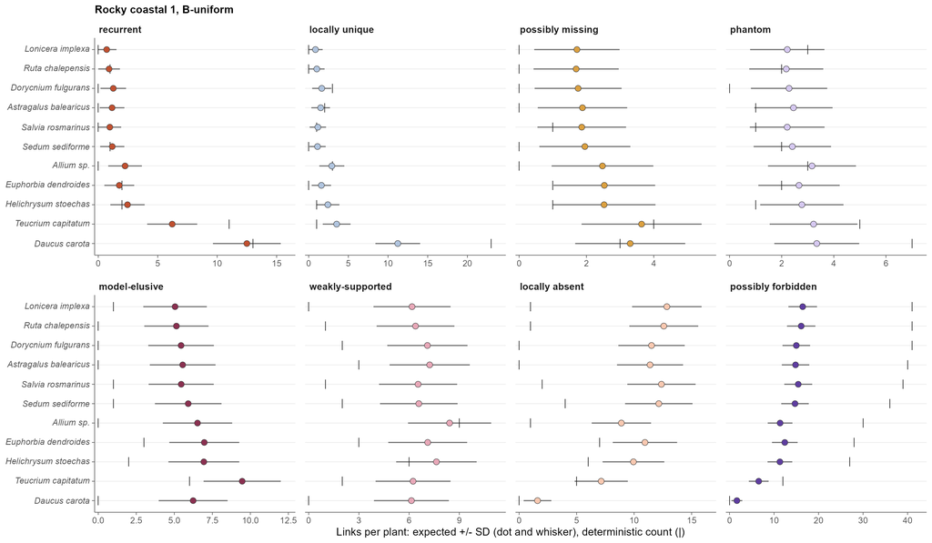

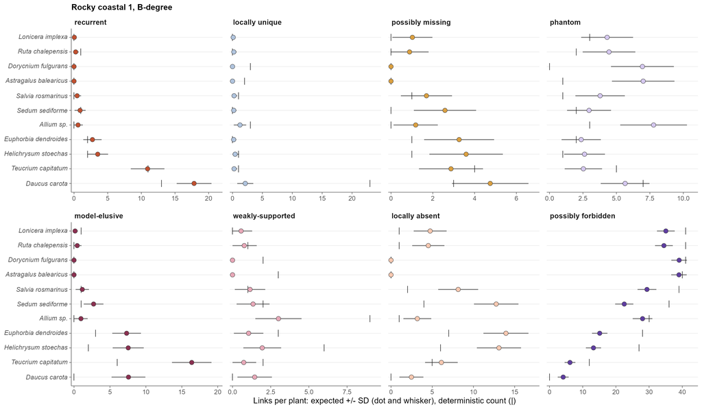

Each dot is the expected number of the plant’s links in that category, the whisker $\pm 1$ SD (cut at zero), and the tick the deterministic count. Plants are ordered by degree, highest at the bottom, as in the maps. Every panel has its own axis, because possibly forbidden runs to tens of links and possibly missing to a few.

The same posteriors as each plant’s composition: a cell is the plant’s average posterior for that category, so every row sums to 1 and a row shows where that plant’s mass goes.

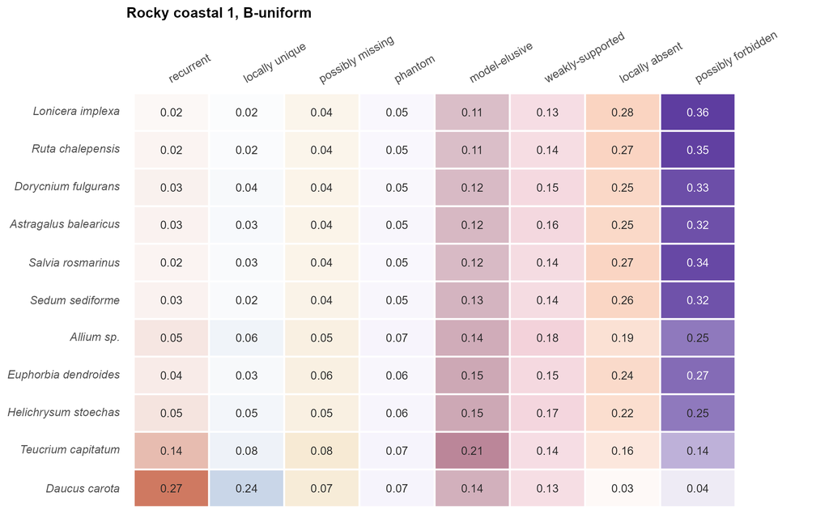

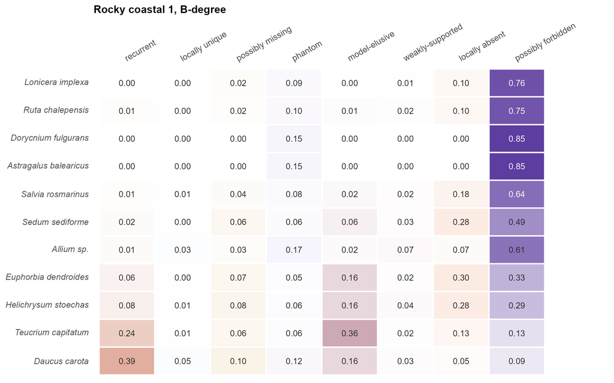

**Observation.** Model-elusive mass on a plant does not mean its links went unpredicted. *Daucus carota* has no model-elusive links in the deterministic assignment, yet an average posterior of 0.16 under B-degree. It comes from its 36 observed links, all of which the model predicted. Model-elusive and recurrent differ only in the model bit, so the posterior splits a realised link between them by how far it trusts the model’s call: $1 - q_i$ under B. 8 of them have a calibrated score below 0.6, so the mass flags weak model calls, not new ecology.

**Methodological decisions.**

*What is summed.* For plant $j$, over its candidate links $i \in j$:

$$E[N_{kj}] = \sum_{i \in j} P(k \mid E_i),
\qquad
\operatorname{SD}(N_{kj}) = \sqrt{\sum_{i \in j} P(k \mid E_i)\,\bigl(1
- P(k \mid E_i)\bigr)}$$

A link’s eight posteriors sum to 1, so a plant’s eight expected counts sum to its number of candidate links, 46 here, not to 1.

*Why the sum and not the average.* The average posterior, the sum divided by the number of candidates, is also a valid summary: it is the **share** of the plant’s candidate links in each category, and its eight values add up to 1. We use the sum for three reasons.

1. **Effort is planned in links, not in shares.** The field question is how many links a plant holds that still need corroboration. The sum answers it directly; the share has to be multiplied back by the number of candidates.
2. **A share means different amounts in different places.** A share of 0.10 is 4.6 links for a plant at Rocky coastal 1 (46 candidates), 1.6 at Pine forest 1 (16 candidates), and 1.1 for a pollinator at Rocky coastal 1 (11 candidates). Sums stay comparable across sites and between plants and pollinators; shares do not.
3. **The SD is in the same units as the answer.** The SD of the sum is in links. The SD of a share shrinks as candidates grow, so it looks more certain for a species with many candidates without saying anything about how many links are at stake.

Within this one site every plant has the same 46 candidates, so the two rank plants identically, and the choice only matters once plants are compared with other sites or with pollinators.

One more alternative was set aside:

- **Counting each link’s most likely category** is winner takes all. A category that is rarely any link’s first choice counts as zero even when it holds real probability across many links: under B-uniform at this site, 4 links have possibly missing as their most likely category, against 25.3 expected. It repeats the problem of hard labels.

The single most probable count was also considered. It always lies within one of the sum (Darroch 1964), so it adds nothing, and unlike the sums the eight do not add up to the candidates.

*The heatmap uses the average.* With $n_j$ the plant’s candidate links,

$$\bar P_{kj} = \frac{E[N_{kj}]}{n_j} = \frac{1}{n_j}\sum_{i \in j} P(k
\mid E_i),
\qquad \sum_k \bar P_{kj} = 1$$

Here the question is a plant’s composition, read across a row, and a share is its natural scale. At this site every $n_j$ is 46, so the heatmap and the counts above carry the same information. Each column runs from white to its category’s colour in the map key, on one intensity scale for all cells: full colour is the highest average posterior in that figure. Values are printed because small shares are hard to tell apart by shade, and the palest category colours never get dark.

*What the SD shows.* How far the true count could plausibly sit from the expected one. Two limits: it treats a plant’s links as independent, but links sharing a plant also share its sampling effort (SI Section S7), so the real spread is wider; and at small counts the spread is skewed, so the whisker is cut at zero rather than read as symmetric.

*Which runs.* B-uniform and B-degree. Both carry the calibrated score, and the prior is the choice that moves the posterior (takeaway under “Where the posterior weight goes”). Heterogeneity is kept, since removing it changes little (takeaway under “Does heterogeneity matter?”).

**Takeaway.** Summed per plant, the posterior turns categories into an effort plan with its uncertainty attached. For possibly missing, the category that calls for more of the same method, expected counts run from 1.7 to 3.6 per plant under B-uniform and from 0.0 to 4.7 under B-degree, led by *Teucrium capitatum* (3.6 ± 1.8) and *Daucus carota* (4.7 ± 1.8) respectively. The degree prior separates plants more. The deterministic count falls outside $\pm 1$ SD in 63 of 88 plant–category cells under B-uniform and 50 under B-degree: the cells where the posterior and the hard labels disagree most about a plant.

### Step 2: one plant, where its posterior mass goes

Step 1 compares plants within a category. Step 2 turns this around: for one plant, it compares its eight categories with each other, to see where that plant’s posterior mass goes. Shown for *Sedum sediforme* and *Teucrium capitatum*; the script draws any plant listed in `FOCAL_PLANTS`.

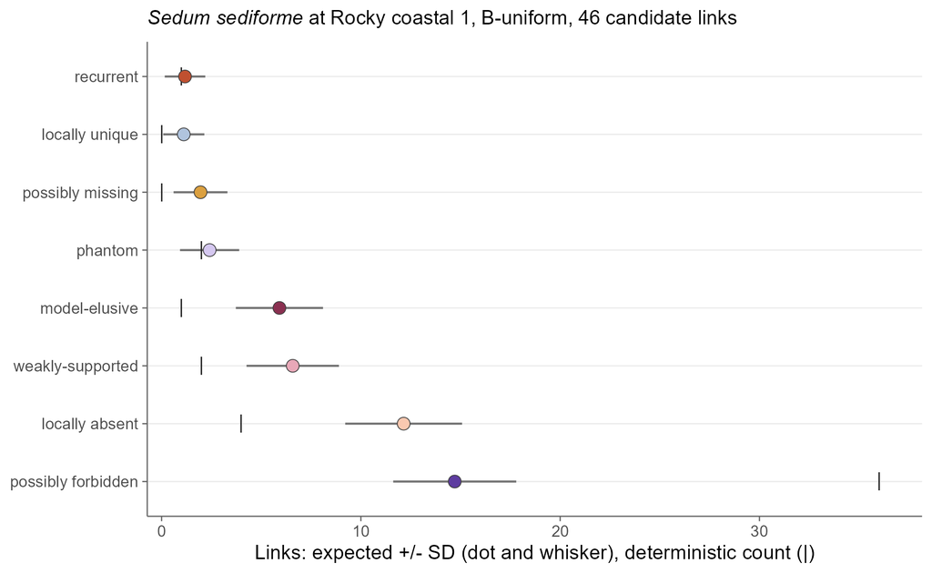

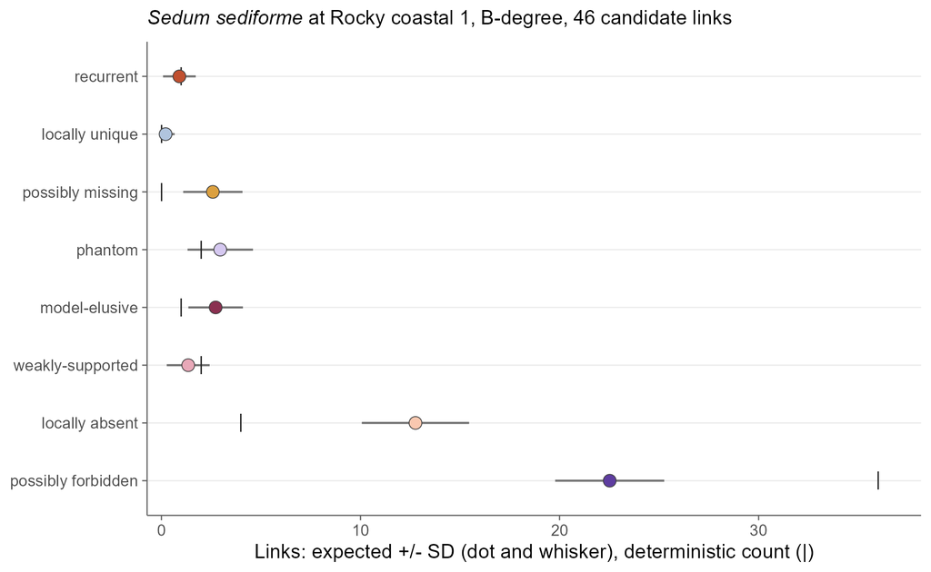

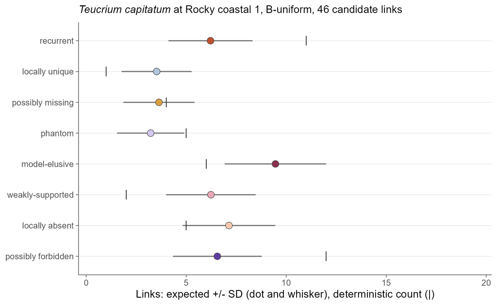

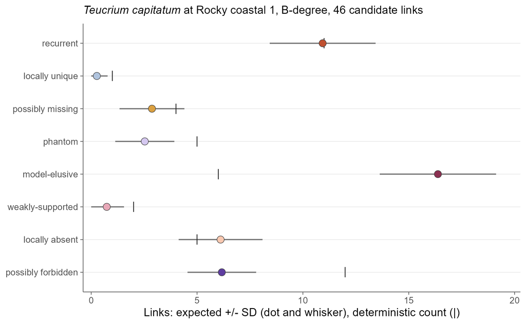

**Methodological decisions.** The values are the step-1 expected counts and SDs for that plant, with the same formulas, so the eight rows add up to its 46 candidate links. Dot, whisker and tick mean what they mean in step 1.

*One axis for all eight rows*, unlike step 1, because the comparison is now between categories of the same plant. *The same axis in both runs’ figures*, so the two can be read against each other directly.

**Takeaway.** Per plant, the posterior shows which categories hold its mass and how far that departs from the hard labels.

- *Sedum sediforme*: most mass in possibly forbidden under B-uniform (14.7 links, 32%) and in possibly forbidden under B-degree (22.5 links, 49%); the deterministic count falls outside $\pm 1$ SD in 6 and 4 of the eight categories.
- *Teucrium capitatum*: most mass in model-elusive under B-uniform (9.5 links, 21%) and in model-elusive under B-degree (16.4 links, 36%); the deterministic count falls outside $\pm 1$ SD in 6 and 5 of the eight categories.

**Open question: the degree prior. 6 of 21 plants and 19 of 69 pollinators are recorded at a single site. Their degree in the replicates is 0, so $\pi_l^{\deg} = \pi_r^{\deg} = 0$ and their locally observed links are forced into categories not realised here: under B-degree, *Astragalus balearicus* and *Dorycnium fulgurans* get no expected links realised here despite 10 observed. The degree prior also draws on the same five sites as the replicate evidence $n$, a partial double count. One fix to weigh: degrees from all six sites, leaving out the pair’s own records.**

## How much is replication worth here?

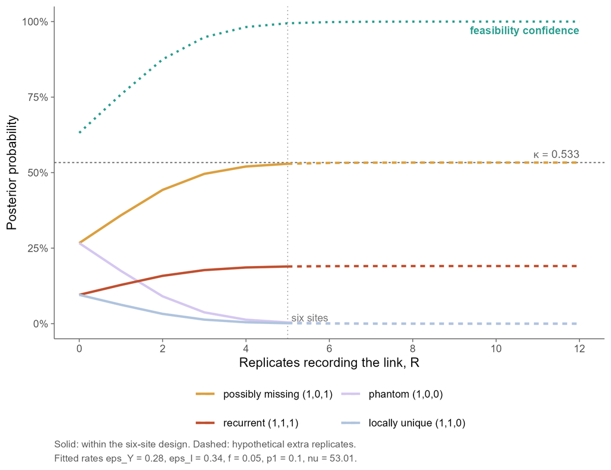

Figure 3a of the manuscript, driven by the rates fitted here rather than illustrative ones. Solid within the six-site design, dashed for hypothetical extra sites.

**Methodological decisions.** The curve comes from the same posterior function as everything above, under A-uniform, swept over the number of replicates, so this figure and the analysis cannot drift apart. The evidence is the possibly-missing signature, predicted, not seen here, and detected in every replicate that could have found it:

$$E = \left(\hat Y = 1,\;\; O_l = 0,\;\; n = R\right), \qquad R = 0, 1, 2,
\ldots$$

Each coloured line is $P(k \mid E)$ for one category. The teal line is **feasibility confidence**, the probability that the link is realised here or realisable elsewhere, whichever category it falls in:

$$\varphi = 1 - P(\text{phantom} \mid E) - P(\text{possibly forbidden}
\mid E)$$

The dashed horizontal line is $\kappa$, defined under the posterior weight figure above.

How fast the curve climbs is set by how far $p_1$ = 0.10 sits above $f$ = 0.05: the wider that gap, the more each recording replicate is worth. The level it climbs toward is $\kappa$, which does not involve $p_1$ at all.

**Takeaway.** A few replicates exhaust what replication can buy here. $\kappa$ = 0.533 follows from the error rates by algebra: it is a structural ceiling, not a measurement, and no amount of sampling passes it. The way past it is a better model or a better local method, which is exactly the corroboration action the framework already prescribes for the categories sitting against it. That is an argument for the framework, not a limitation of it.

## The main-text figure on these rates

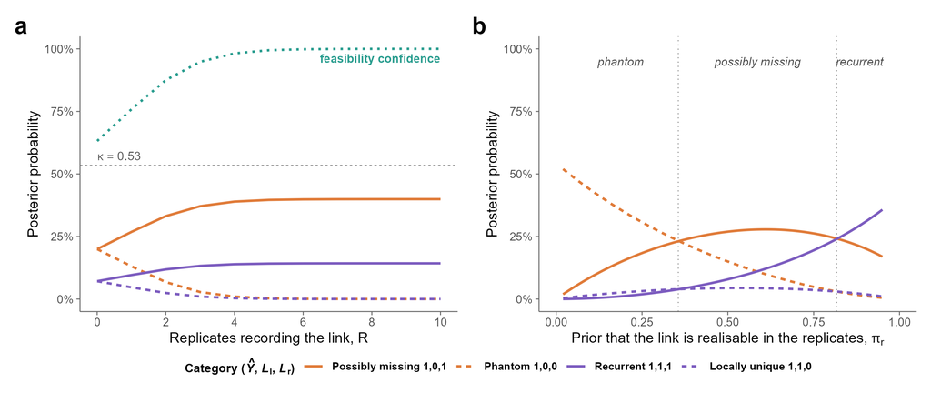

The manuscript’s Figure 3, rebuilt on the fitted rates. Panel **a** is the accumulation above, and panel **b** asks what an informative prior does to the same evidence.

**Methodological decisions.** B-uniform in both panels, so the model enters through the prior and the other two bits start at $\tfrac12$. Both panels come from the same `posterior()` as the rest of the analysis.

*Why $\pi_Y$ is one number.* Under B every link carries its own calibrated score $q_i$, so there is no single curve to draw: the 380 predicted links would give 380 of them. The figure shows one link, so it needs one score, and the evidence it shows is a **predicted** link. We take the median $q$ among predicted links, 0.54, which is the typical link of the kind drawn. The choice moves the curve’s ceiling and nothing else, since $\pi_Y$ enters only as $q$ in $\kappa_B$ below: the quartiles of $q$, 0.44 and 0.69, would give 0.32 and 0.51 in place of 0.40. A link-specific figure would use that link’s own $q$.

*Panel a* sweeps the replicates with the possibly-missing signature, as in the figure above, to $R$ = 10.

*Panel b* fixes the evidence at the design, $R$ = 5 replicates with the link recorded in at least one ($O_r = 1$), and sweeps the prior instead. The replicate axis is coarsened to that single bit, which is the framework as first presented. $\pi_l$ is held at $0.9\,\pi_r$, so both priors move together, as in the illustrative figure.

*Two ceilings.* $\kappa$ is derived with the model in the likelihood. With the model in the prior, the same algebra holds with $1 - \epsilon_Y$ replaced by $q$:

$$\kappa = \frac{(1-\epsilon_Y)(1-f)}{(1-f)+\epsilon_l} = 0.53,
\qquad
\kappa_B = \frac{q\,(1-f)}{(1-f)+\epsilon_l} = 0.40$$

So the curve plateaus below the drawn $\kappa$ line, by exactly the ratio $q / (1 - \epsilon_Y)$ = 0.75.

**Takeaway.** Replication settles feasibility and little else. Feasibility confidence runs from 63% with no replicates to 99% at the 5 the design provides. Possibly missing reaches 0.396 there, against 0.399 in the limit, and is already within 5% of that plateau by $R$ = 4. Extra sites would add almost nothing.

The curve never reaches $\kappa$: replication is spent by the fifth replicate, yet possibly missing settles 0.13 below the line, because a link the model scores at 0.54 cannot be carried past $\kappa_B$ = 0.40 however often the replicates record it. $\kappa$ is reached only where the model itself is confident: it would take $q = 1 - \epsilon_Y$ = 0.72, which 18% of predicted links exceed. So the gap in panel a is the price of letting each link speak with its own score instead of the model’s average reliability, and closing it needs a better model, not more sites.

Panel b says what does move the answer: the same evidence reads as phantom, then possibly missing, then recurrent as the prior rises, with the switches at $\pi_r$ = 0.36 and 0.82. What is known about the pair decides the reading, which is the argument for the degree prior and also the reason its open question above matters.